# Late spring update of the r2dii suite!

r2dii

methodology

New terminologies introduced, new plotting methodology, and the `target_sda()` function gets some TLC.

Jackson Hoffart https://github.com/jdhoffa  
2022-05-05

The PACTA team is proud to announce that the latest versions of the `r2dii` suite are now available on CRAN! This update introduced a minor version bump to each of the r2dii packages:

- r2dii.data 0.3.0
- r2dii.match 0.1.0
- r2dii.analysis 0.2.0
- r2dii.plot 0.3.0

You can install these packages from CRAN with:

```r
install.packages("r2dii.data")
# etc. for each of the packages
```

and load them into an R session using:

```r
library(dplyr)
library(r2dii.data)
library(r2dii.match)
library(r2dii.analysis)
library(r2dii.plot)
```

# ALD will now be referred to as ABCD

We have updated our internal terminology from Asset-Level Data (ALD), to the more accurate Asset-Based Company Data (ABCD). In the code, this results in the update of `ald -> abcd` in many crucial arguments and datasets.

In `r2dii.data` this results in the new dataset `abcd_demo`, which is an analog of `ald_demo`:

```r
abcd_demo
```

```
# A tibble: 17,668 × 14
   company_id name_company     lei   sector technology production_unit
   <chr>      <chr>            <chr> <chr>  <chr>      <chr>
 1 1          aba hydropower … 8360… power  hydrocap   MW
 2 1          aba hydropower … 8360… power  hydrocap   MW
 3 1          aba hydropower … 8360… power  hydrocap   MW
 4 1          aba hydropower … 8360… power  hydrocap   MW
 5 1          aba hydropower … 8360… power  hydrocap   MW
 6 1          aba hydropower … 8360… power  hydrocap   MW
 7 1          aba hydropower … 8360… power  hydrocap   MW
 8 1          aba hydropower … 8360… power  hydrocap   MW
 9 1          aba hydropower … 8360… power  hydrocap   MW
10 1          aba hydropower … 8360… power  hydrocap   MW
# … with 17,658 more rows, and 8 more variables: year <int>,
#   production <dbl>, emission_factor <dbl>,
#   country_of_domicile <chr>, plant_location <chr>,
#   is_ultimate_owner <lgl>, abcd_timestamp <chr>,
#   emission_factor_unit <chr>
```

Notice that `ald_demo` can still be used, but will yield a warning. This dataset will be removed in the next release:

```r
ald_demo
```

```
Warning: The dataset `ald_demo`is superseded as of r2dii.data 0.3.0 (expected July 2022).
Please use `abcd_demo` instead.
Read this blog post to learn more:
https://2degreesinvesting.github.io/posts/2022-03-02-ald-becomes-abcd/
```

```
# A tibble: 17,668 × 14
   company_id name_company     lei   sector technology production_unit
   <chr>      <chr>            <chr> <chr>  <chr>      <chr>
 1 1          aba hydropower … 8360… power  hydrocap   MW
 2 1          aba hydropower … 8360… power  hydrocap   MW
 3 1          aba hydropower … 8360… power  hydrocap   MW
 4 1          aba hydropower … 8360… power  hydrocap   MW
 5 1          aba hydropower … 8360… power  hydrocap   MW
 6 1          aba hydropower … 8360… power  hydrocap   MW
 7 1          aba hydropower … 8360… power  hydrocap   MW
 8 1          aba hydropower … 8360… power  hydrocap   MW
 9 1          aba hydropower … 8360… power  hydrocap   MW
10 1          aba hydropower … 8360… power  hydrocap   MW
# … with 17,658 more rows, and 8 more variables: year <int>,
#   production <dbl>, emission_factor <dbl>,
#   country_of_domicile <chr>, plant_location <chr>,
#   is_ultimate_owner <lgl>, abcd_timestamp <chr>,
#   emission_factor_unit <chr>
```

In `r2dii.match` and `r2dii.analysis`, several functions have had the `ald` argument superseded by `abcd`. For example:

```r
# this works
match_name(loanbook_demo, abcd_demo)
```

```
# A tibble: 410 × 28
   id_loan id_direct_loantaker name_direct_loantaker  id_intermediate…
   <chr>   <chr>               <chr>                  <chr>
 1 L1      C294                Yuamen Xinneng Therma… <NA>
 2 L3      C292                Yuama Ethanol Llc      IP5
 3 L3      C292                Yuama Ethanol Llc      IP5
 4 L5      C305                Yukon Energy Corp 1736 <NA>
 5 L5      C305                Yukon Energy Corp 1736 <NA>
 6 L6      C304                Yukon Development Corp <NA>
 7 L6      C304                Yukon Development Corp <NA>
 8 L8      C303                Yueyang City Construc… <NA>
 9 L9      C301                Yuedxiu Corp One       IP10
10 L10     C302                Yuexi County AAAA Xin… <NA>
# … with 400 more rows, and 24 more variables:
#   name_intermediate_parent_1 <chr>, id_ultimate_parent <chr>,
#   name_ultimate_parent <chr>, loan_size_outstanding <dbl>,
#   loan_size_outstanding_currency <chr>,
#   loan_size_credit_limit <dbl>,
#   loan_size_credit_limit_currency <chr>,
#   sector_classification_system <chr>, …
```

```r
# this also works
match_name(
  loanbook = loanbook_demo,
  abcd = abcd_demo
)
```

```
# A tibble: 410 × 28
   id_loan id_direct_loantaker name_direct_loantaker  id_intermediate…
   <chr>   <chr>               <chr>                  <chr>
 1 L1      C294                Yuamen Xinneng Therma… <NA>
 2 L3      C292                Yuama Ethanol Llc      IP5
 3 L3      C292                Yuama Ethanol Llc      IP5
 4 L5      C305                Yukon Energy Corp 1736 <NA>
 5 L5      C305                Yukon Energy Corp 1736 <NA>
 6 L6      C304                Yukon Development Corp <NA>
 7 L6      C304                Yukon Development Corp <NA>
 8 L8      C303                Yueyang City Construc… <NA>
 9 L9      C301                Yuedxiu Corp One       IP10
10 L10     C302                Yuexi County AAAA Xin… <NA>
# … with 400 more rows, and 24 more variables:
#   name_intermediate_parent_1 <chr>, id_ultimate_parent <chr>,
#   name_ultimate_parent <chr>, loan_size_outstanding <dbl>,
#   loan_size_outstanding_currency <chr>,
#   loan_size_credit_limit <dbl>,
#   loan_size_credit_limit_currency <chr>,
#   sector_classification_system <chr>, …
```

```r
# this also works, but will throw a warning
match_name(
  loanbook = loanbook_demo,
  ald = abcd_demo # this argument is being deprecated
)
```

```
# A tibble: 410 × 28
   id_loan id_direct_loantaker name_direct_loantaker  id_intermediate…
   <chr>   <chr>               <chr>                  <chr>
 1 L1      C294                Yuamen Xinneng Therma… <NA>
 2 L3      C292                Yuama Ethanol Llc      IP5
 3 L3      C292                Yuama Ethanol Llc      IP5
 4 L5      C305                Yukon Energy Corp 1736 <NA>
 5 L5      C305                Yukon Energy Corp 1736 <NA>
 6 L6      C304                Yukon Development Corp <NA>
 7 L6      C304                Yukon Development Corp <NA>
 8 L8      C303                Yueyang City Construc… <NA>
 9 L9      C301                Yuedxiu Corp One       IP10
10 L10     C302                Yuexi County AAAA Xin… <NA>
# … with 400 more rows, and 24 more variables:
#   name_intermediate_parent_1 <chr>, id_ultimate_parent <chr>,
#   name_ultimate_parent <chr>, loan_size_outstanding <dbl>,
#   loan_size_outstanding_currency <chr>,
#   loan_size_credit_limit <dbl>,
#   loan_size_credit_limit_currency <chr>,
#   sector_classification_system <chr>, …
```

Similar changes have been made to `target_market_share` and `target_sda`. Please take the time now to make the necessary updates in your code of `ald` to `abcd`, as the former will be fully deprecated by the next release.

See this blog post for more information: https://2degreesinvesting.github.io/posts/2022-03-02-ald-becomes-abcd/

# New, more consistent way of plotting volume trajectories

In previous iterations of `r2dii`, the value plotted in the volume trajectory charts was simply normalized production. We found several issues with this approach, perhaps the most confusing of which was an issue where corporate economy benchmarks would appear to be aligned with different scenarios, depending on which input loanbook was used.

This problem has been solved, by plotting the following portfolio-invariant quantities, either the percent change as a percentage of the initial technology (for high-carbon technologies):

$$\frac{p_i^{target}(t) -
p_i(t_0)}{p_i(t_0)} = \frac{s_i(t)-s_i(t_0)}{s_i(t_0)}$$

or as a percentage of the initial sector (for low-carbon technologies):

$$\frac{p_i^{target}(t) -
p_i(t_0)}{P(t_0)} = \frac{s_i(t)-s_i(t_0)}{S(t_0)}$$

The explanation of this decision is very detailed, and can be found here: https://2degreesinvesting.github.io/posts/2022-05-02-market-share-target-setting-methodology-calculation-and-plotting/

## Resulting changes to r2dii.analysis and r2dii.plot

In `r2dii.analysis`, the result is two new columns in the `target_market_share()` output, `scope`, `percentage_of_initial_production_by_scope`:

```r
market_share_targets <- loanbook_demo %>%
  match_name(abcd_demo) %>%
  prioritize() %>%
  target_market_share(abcd_demo, scenario_demo_2020, region_isos_demo)

select(market_share_targets, technology, scope, percentage_of_initial_production_by_scope)
```

```
# A tibble: 1,790 × 3
   technology scope  percentage_of_initial_production_by_scope
   <chr>      <chr>                                      <dbl>
 1 electric   sector                                   0
 2 electric   sector                                   0
 3 electric   sector                                   0
 4 electric   sector                                   0
 5 electric   sector                                   0.00352
 6 electric   sector                                   0.00108
 7 electric   sector                                   0.00653
 8 electric   sector                                   0.00137
 9 electric   sector                                   0.00705
10 electric   sector                                   0.00213
# … with 1,780 more rows
```

By default, `r2dii.plot::qplot_trajectory` will now plot these values:

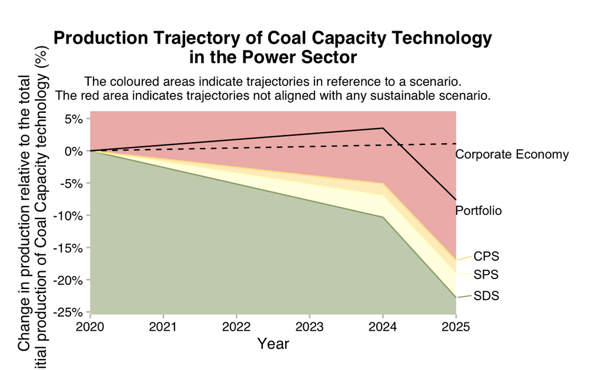

```r
data <- market_share_targets %>% filter(
  sector == "power" &
    technology == "coalcap" &
    region == "global" &
    scenario_source == "demo_2020"
)

qplot_trajectory(data)
```

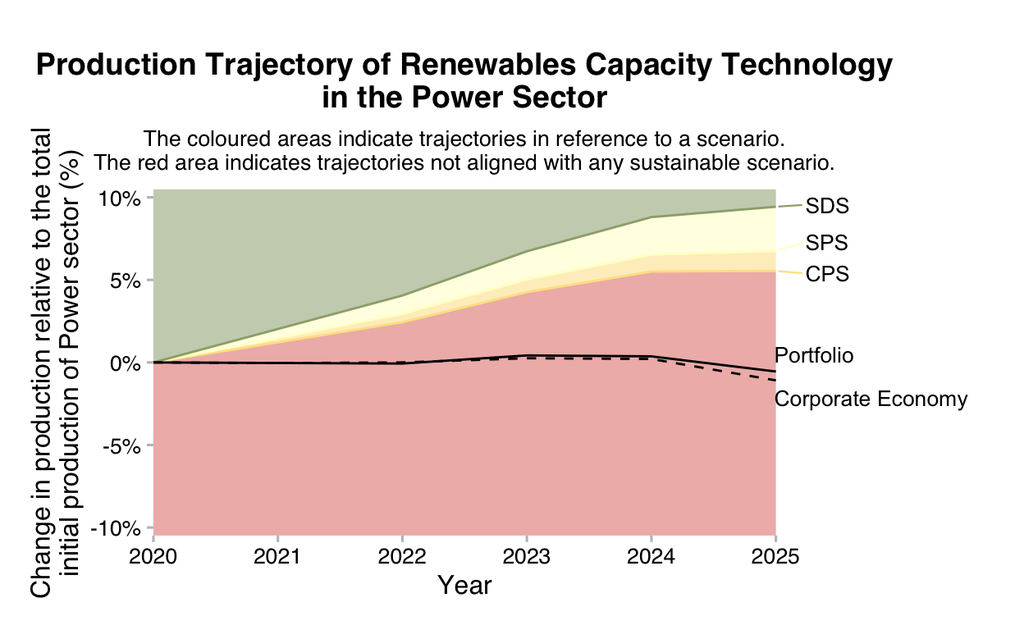

```r
data <- market_share_targets %>% filter(
  sector == "power" &
    technology == "renewablescap" &
    region == "global" &
    scenario_source == "demo_2020"
)

qplot_trajectory(data)
```

# `target_sda()` gets some love

Finally, some tweaks and enhancements were made to the `target_sda()` function of `r2dii.analysis`, in particular: * `target_sda()` now only outputs data for `sector` values that are in all three input datasets (`data`, `ald` and `co2_intensity_scenario`) (#390).

- `target_sda()` now outputs unweighted `emission_factor` if `by_company` is `TRUE` (#376).
- `target_sda()` gains `region_isos` argument (#323).

As always, this progress is thanks to the valued contributions from the open source community.